# CaseStudy2Lull

```r
CM = confusionMatrix(table(cltest,test$Attrition))
CM
```

```
## Confusion Matrix and Statistics
##
##
## cltest  No Yes
##    No  219  40
##    Yes   0   2
##
##                Accuracy : 0.8467
##                  95% CI : (0.7972, 0.8882)
##     No Information Rate : 0.8391
##     P-Value [Acc > NIR] : 0.4072
##
##                   Kappa : 0.0774
##
##  Mcnemar's Test P-Value : 6.984e-10
##
##             Sensitivity : 1.00000
##             Specificity : 0.04762
##          Pos Pred Value : 0.84556
##          Neg Pred Value : 1.00000
##              Prevalence : 0.83908
##          Detection Rate : 0.83908
##    Detection Prevalence : 0.99234
##       Balanced Accuracy : 0.52381
##
##        'Positive' Class : No
##
```

LASSO Feature Selection to use in Logistical Regression Attrition Model and basis for Linear Regression Income Model

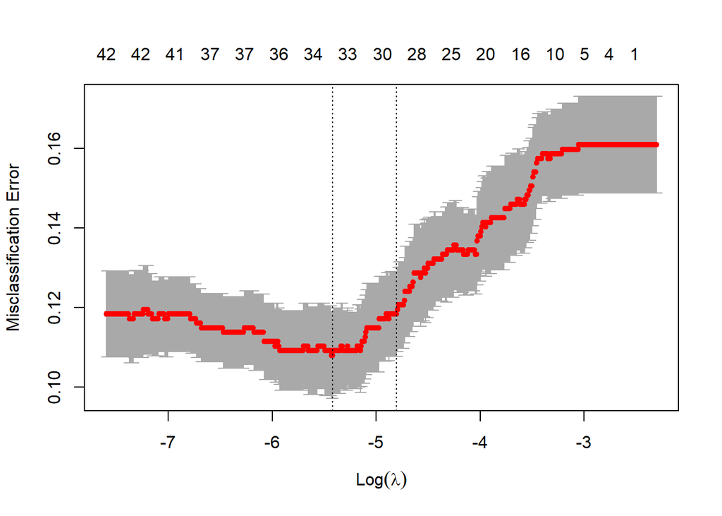

```r
lasso.y <-employee[,c("Attrition")]

lasso.x <- model.matrix(Attrition~ Age + BusinessTravel + DailyRate + Department + DistanceFromHome + Education + EducationField +EmployeeCount +   EmployeeNumber + EnvironmentSatisfaction + Gender + HourlyRate + JobInvolvement + JobLevel + JobRole + JobSatisfaction + MaritalStatus + MonthlyIncome + MonthlyRate + NumCompaniesWorked + OverTime + PerformanceRating + RelationshipSatisfaction + StandardHours  + StockOptionLevel + TotalWorkingYears + TrainingTimesLastYear +WorkLifeBalance + YearsAtCompany + YearsInCurrentRole + YearsSinceLastPromotion + YearsWithCurrManager
,employee)


###  LASSO Model for Feature Selection
lasso.mdl.cvfit <- cv.glmnet(lasso.x, lasso.y, family = "binomial", type.measure = "class", nlambda = 1000)
plot(lasso.mdl.cvfit)
```

```r
coef(lasso.mdl.cvfit)
```

```
## 48 x 1 sparse Matrix of class "dgCMatrix"
##                                              1
## (Intercept)                       2.431166e+00
## (Intercept)                       .
## Age                              -2.140829e-02
## BusinessTravelTravel_Frequently   4.287978e-01
## BusinessTravelTravel_Rarely       .
## DailyRate                        -5.934412e-05
## DepartmentResearch & Development -1.754303e-01
## DepartmentSales                   .
## DistanceFromHome                  2.711976e-02
## Education                         .
## EducationFieldLife Sciences       .
## EducationFieldMarketing           .
## EducationFieldMedical             .
## EducationFieldOther               .
## EducationFieldTechnical Degree    2.160689e-01
## EmployeeCount                     .
## EmployeeNumber                    .
## EnvironmentSatisfaction          -1.773350e-01
## GenderMale                        1.715702e-02
## HourlyRate                        3.889946e-03
## JobInvolvement                   -6.150345e-01
## JobLevel                          .
## JobRoleHuman Resources            2.857016e-01
## JobRoleLaboratory Technician      2.682875e-01
## JobRoleManager                    .
## JobRoleManufacturing Director    -1.052099e+00
## JobRoleResearch Director         -6.450810e-01
## JobRoleResearch Scientist         .
## JobRoleSales Executive            .
## JobRoleSales Representative       1.019709e+00
## JobSatisfaction                  -3.112936e-01
## MaritalStatusMarried              1.749374e-01
## MaritalStatusSingle               7.594999e-01
## MonthlyIncome                     .
## MonthlyRate                      -3.337732e-06
## NumCompaniesWorked                1.266096e-01
## OverTimeYes                       1.502123e+00
## PerformanceRating                 .
## RelationshipSatisfaction         -1.175047e-01
## StandardHours                     .
## StockOptionLevel                 -1.376822e-01
## TotalWorkingYears                -4.208574e-02
## TrainingTimesLastYear            -1.453440e-01
## WorkLifeBalance                  -3.195260e-01
## YearsAtCompany                    .
## YearsInCurrentRole               -4.711800e-02
## YearsSinceLastPromotion           1.241853e-01
## YearsWithCurrManager             -5.379575e-02
```

### Create Test and Training Data Sets ### Logistical Regression based on LASSO feature Selection

Data is Skewed for Attrition Reponse, so first split the data into two sets for Yes and No responses. Then divide 80 percent to training and 20 percent test on the individual datasets. Then put the two back together

This will insure the YES responses are adequately represented. If we do not do this, we risk having no YES responses in one of the created datasets

```r
 #Train and Test Split 80%/20%, with a seed of 10 so all members of the group can use to compare results on the same basis
#The split wa done using the Yes and No Attrition Values Seperately to keep it balanced

AttritionYes = employee %>%  filter(Attrition == "Yes")
AttritionNo = employee %>%  filter(Attrition == "No")
set.seed(9)
trainInd = sample(dim(AttritionYes)[1],round(.8*dim(AttritionYes)[1]))
trainYES = AttritionYes[trainInd,]
testYES = AttritionYes[-trainInd,]

trainInd = sample(dim(AttritionNo)[1],round(.8*dim(AttritionNo)[1]))
train = AttritionNo[trainInd,]
test = AttritionNo[-trainInd,]

train = rbind(train,trainYES)
test = rbind(test,testYES)
table(test$Attritiontion)
```

```
## < table of extent 0 >
```

```r
lr.employee <-glm(Attrition ~ Age + BusinessTravel + DistanceFromHome + EducationField + EnvironmentSatisfaction + HourlyRate + JobInvolvement + JobRole + JobSatisfaction  + MaritalStatus*Gender + MonthlyRate + NumCompaniesWorked + OverTime + RelationshipSatisfaction + StockOptionLevel + TotalWorkingYears + TrainingTimesLastYear  + WorkLifeBalance + YearsInCurrentRole + YearsSinceLastPromotion + YearsWithCurrManager,data=train,family=binomial(link="logit"))

lr.employee.pred2 <- data.frame(predict(lr.employee, newdata  = test, type = "response"))
lr.employee.pred2 = lr.employee.pred2 %>% mutate(pred = ifelse(lr.employee.pred2 <0.25, "No", "Yes"))

table(lr.employee.pred2$pred)
```

```
##
##  No Yes
## 130  44
```

```r
predtble = as.factor(lr.employee.pred2$pred)
predtble  <-relevel(predtble, ref = "No")
Truth<-test$Attrition
confmtx = as.matrix(table(predtble,Truth))
CM = confusionMatrix(confmtx)
CM
```

```
## Confusion Matrix and Statistics
##
##         Truth
## predtble  No Yes
##      No  123   7
##      Yes  23  21
##
##                Accuracy : 0.8276
##                  95% CI : (0.7631, 0.8805)
##     No Information Rate : 0.8391
##     P-Value [Acc > NIR] : 0.70289
##
##                   Kappa : 0.4813
##
##  Mcnemar's Test P-Value : 0.00617
##
##             Sensitivity : 0.8425
##             Specificity : 0.7500
##          Pos Pred Value : 0.9462
##          Neg Pred Value : 0.4773
##              Prevalence : 0.8391
##          Detection Rate : 0.7069
##    Detection Prevalence : 0.7471
##       Balanced Accuracy : 0.7962
##
##        'Positive' Class : No
##
```

### Create Predcition Spreadsheet from Logistical Regression Model I

```r
lr.employee.predA <- data.frame(predict(lr.employee, newdata  = employeenoatt, type = "response"))
lr.employee.predA = lr.employee.predA %>% mutate(pred = ifelse(lr.employee.predA <0.25, "No", "Yes"))

preddfA = NewAttr=data.frame(lr.employee.predA[,c(2)])
names(preddfA) <- c("PredictAttrition")
AttrPred <- cbind(employeenoatt[1],preddfA)

write.csv(AttrPred,'c:/School Stuff/DS/Doing DS/Project2/Case2PredictionsLull Attrition.csv')
```

Running a second LR Model on the same test/train datasets as above This model was created by hand using only Data Analysis graphs

```r
lr.employee <-glm(Attrition~Age*TotalWorkingYears+ WorkLifeBalance  + NumCompaniesWorked + StockOptionLevel +JobLevel +JobInvolvement + MaritalStatus*Gender + YearsAtCompany + YearsWithCurrManager,data=train,family=binomial(link="logit"))

lr.employee.pred2 <- data.frame(predict(lr.employee, newdata  = test, type = "response"))
lr.employee.pred2 = lr.employee.pred2 %>% mutate(pred = ifelse(lr.employee.pred2 <0.25, "No", "Yes"))

table(lr.employee.pred2$pred)
```

```
##
##  No Yes
## 122  52
```

```r
predtble = as.factor(lr.employee.pred2$pred)
predtble  <-relevel(predtble, ref = "No")
Truth<-test$Attrition
confmtx = as.matrix(table(predtble,Truth))
CM = confusionMatrix(confmtx)
CM
```

```
## Confusion Matrix and Statistics
##
##         Truth
## predtble  No Yes
##      No  110  12
##      Yes  36  16
##
##                Accuracy : 0.7241
##                  95% CI : (0.6514, 0.7891)
##     No Information Rate : 0.8391
##     P-Value [Acc > NIR] : 0.9999580
##
##                   Kappa : 0.2413
##
##  Mcnemar's Test P-Value : 0.0009009
##
##             Sensitivity : 0.7534
##             Specificity : 0.5714
##          Pos Pred Value : 0.9016
##          Neg Pred Value : 0.3077
##              Prevalence : 0.8391
##          Detection Rate : 0.6322
##    Detection Prevalence : 0.7011
##       Balanced Accuracy : 0.6624
##
##        'Positive' Class : No
##
```

### Test for Attrition Classification on Random Forest based on reduced dataset by EDA Plots

```r
#### Try Random Forest to see what model looks like
employee_reducedrf = employee[,c('WorkLifeBalance','Education','StockOptionLevel','JobLevel','Department','OverTime','TotalWorkingYears','YearsAtCompany','YearsWithCurrManager','Attrition')]


employee.rf <-randomForest(Attrition~.,data=employee_reducedrf,mtry=10,ntree=500,importance=T)
summary(employee.rf)
```

```
##                 Length Class  Mode
## call               6   -none- call
## type               1   -none- character
## predicted        870   factor numeric
## err.rate        1500   -none- numeric
## confusion          6   -none- numeric
## votes           1740   matrix numeric
## oob.times        870   -none- numeric
## classes            2   -none- character
## importance        36   -none- numeric
## importanceSD      27   -none- numeric
## localImportance    0   -none- NULL
## proximity          0   -none- NULL
## ntree              1   -none- numeric
## mtry               1   -none- numeric
## forest            14   -none- list
## y                870   factor numeric
## test               0   -none- NULL
## inbag              0   -none- NULL
## terms              3   terms  call
```

```r
table(employee.rf$predicted,employee_reducedrf$Attrition)
```

```
##
##        No Yes
##   No  680  92
##   Yes  50  48
```

```r
CM = confusionMatrix(table(employee.rf$predicted,employee_reducedrf$Attrition))
CM
```

```
## Confusion Matrix and Statistics
##
##
##        No Yes
##   No  680  92
##   Yes  50  48
##
##                Accuracy : 0.8368
##                  95% CI : (0.8105, 0.8607)
##     No Information Rate : 0.8391
##     P-Value [Acc > NIR] : 0.5950295
##
##                   Kappa : 0.3122
##
##  Mcnemar's Test P-Value : 0.0005803
##
##             Sensitivity : 0.9315
##             Specificity : 0.3429
##          Pos Pred Value : 0.8808
##          Neg Pred Value : 0.4898
##              Prevalence : 0.8391
##          Detection Rate : 0.7816
##    Detection Prevalence : 0.8874
##       Balanced Accuracy : 0.6372
##
##        'Positive' Class : No
##
```

### Linear Regression Model for Income Prediction

```r
#split datasets yes/no
AttritionYes = employee %>%  filter(Attrition == "Yes")
AttritionNo = employee %>%  filter(Attrition == "No")

#Redo Test/Train split - same as done before
set.seed(9)
trainInd = sample(dim(AttritionYes)[1],round(.8*dim(AttritionYes)[1]))
trainYES = employee[trainInd,]
testYES = employee[-trainInd,]

trainInd = sample(dim(AttritionNo)[1],round(.8*dim(AttritionNo)[1]))
train = AttritionNo[trainInd,]
test = AttritionNo[-trainInd,]

train = rbind(train,trainYES)
test = rbind(test,testYES)
table(test$Attribution)
```

```
## < table of extent 0 >
```

```r
###  Added Interactions for Joblevel and Job Role, Business Travel and Gender, Total Working Years and Age, Years in current Role and  Current Manager

lr.employee.inc <-lm(MonthlyIncome ~ JobLevel*JobRole + Department  +  BusinessTravel*Gender + DistanceFromHome + EducationField*Education + EnvironmentSatisfaction + HourlyRate*MonthlyRate   + JobInvolvement  + JobSatisfaction + MaritalStatus  + NumCompaniesWorked  + OverTime + RelationshipSatisfaction + StockOptionLevel  + TotalWorkingYears*Age + TrainingTimesLastYear  + WorkLifeBalance + YearsSinceLastPromotion + YearsInCurrentRole*YearsWithCurrManager,data=train)

RMSE = sqrt(mean(lr.employee.inc$residuals^2))
RMSE
```

```
## [1] 988.333
```

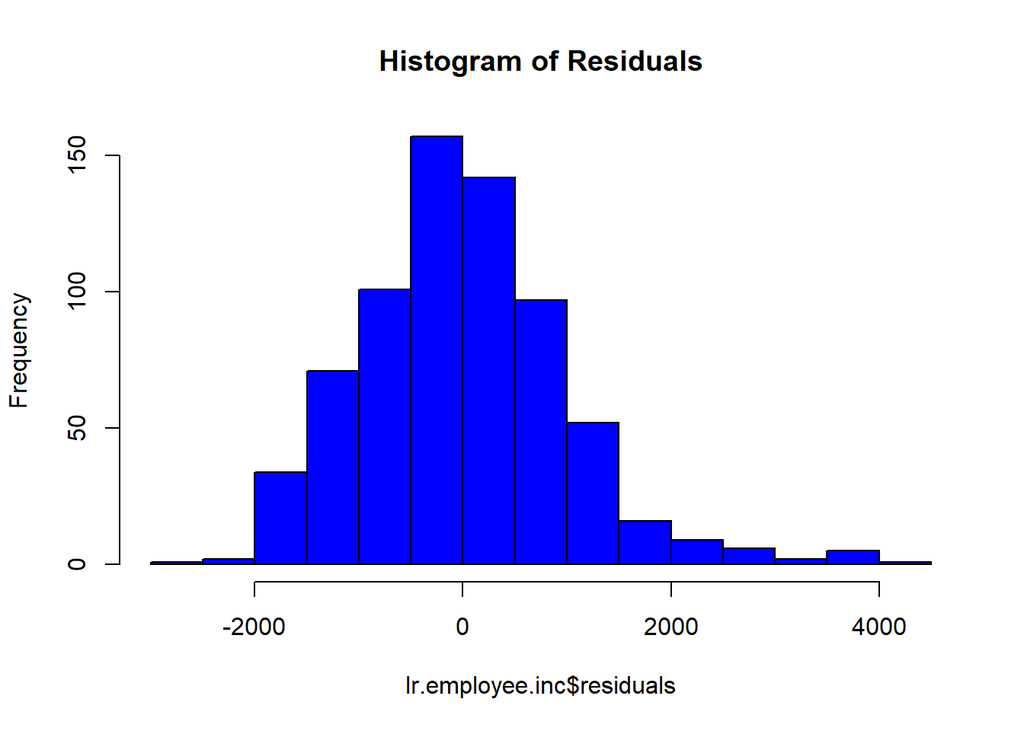

```r
####  Histogram of Residuals

 hist(lr.employee.inc$residuals, col = "blue", main = "Histogram of Residuals")
```

```r
####  Shows voiation of Normality so Log Monthly Income

lr.employee.inc <-lm(log(MonthlyIncome) ~ JobLevel*JobRole + Department  +  BusinessTravel*Gender + DistanceFromHome + EducationField*Education + EnvironmentSatisfaction + HourlyRate*MonthlyRate   + JobInvolvement  + JobSatisfaction + MaritalStatus  + NumCompaniesWorked  + OverTime + RelationshipSatisfaction + StockOptionLevel  + TotalWorkingYears*Age + TrainingTimesLastYear  + WorkLifeBalance + YearsSinceLastPromotion + YearsInCurrentRole*YearsWithCurrManager,data=train)


RMSE = sqrt(mean(lr.employee.inc$residuals^2))
RMSE
```

```
## [1] 0.1990818
```

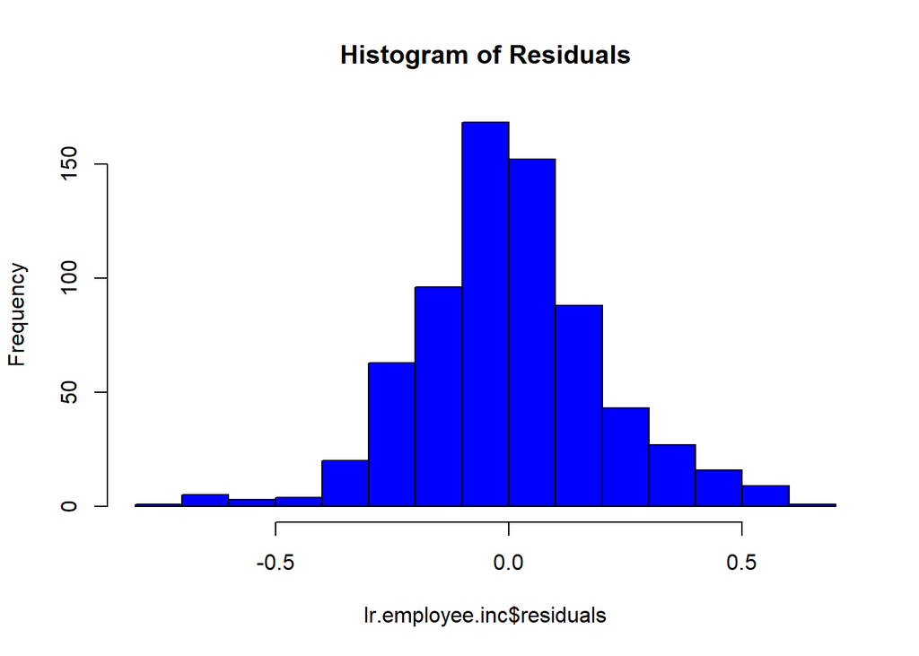

```r
####  Histogram of Residuals

 hist(lr.employee.inc$residuals, col = "blue", main = "Histogram of Residuals")
```

```r
summary(lr.employee.inc)
```

```
##
## Call:
## lm(formula = log(MonthlyIncome) ~ JobLevel * JobRole + Department +
##     BusinessTravel * Gender + DistanceFromHome + EducationField *
##     Education + EnvironmentSatisfaction + HourlyRate * MonthlyRate +
##     JobInvolvement + JobSatisfaction + MaritalStatus + NumCompaniesWorked +
##     OverTime + RelationshipSatisfaction + StockOptionLevel +
##     TotalWorkingYears * Age + TrainingTimesLastYear + WorkLifeBalance +
##     YearsSinceLastPromotion + YearsInCurrentRole * YearsWithCurrManager,
##     data = train)
##
## Residuals:
##      Min       1Q   Median       3Q      Max
## -0.74798 -0.11415 -0.00636  0.10787  0.63484
##
## Coefficients:
##                                              Estimate Std. Error t value
## (Intercept)                                 7.259e+00  3.178e-01  22.840
## JobLevel                                    3.995e-01  4.472e-02   8.932
## JobRoleHuman Resources                     -2.913e-01  1.946e-01  -1.497
## JobRoleLaboratory Technician               -2.197e-01  1.226e-01  -1.792
## JobRoleManager                              1.112e+00  2.647e-01   4.199
## JobRoleManufacturing Director              -1.878e-02  1.399e-01  -0.134
## JobRoleResearch Director                    9.425e-01  1.864e-01   5.055
## JobRoleResearch Scientist                  -4.559e-01  1.242e-01  -3.671
## JobRoleSales Executive                      6.219e-02  1.475e-01   0.422
## JobRoleSales Representative                -4.671e-01  1.860e-01  -2.511
## DepartmentResearch & Development            4.288e-02  1.003e-01   0.427
## DepartmentSales                            -1.523e-02  1.016e-01  -0.150
## BusinessTravelTravel_Frequently            -2.483e-02  5.285e-02  -0.470
## BusinessTravelTravel_Rarely                -3.176e-02  4.570e-02  -0.695
## GenderMale                                 -5.114e-02  5.344e-02  -0.957
## DistanceFromHome                           -2.281e-04  1.064e-03  -0.214
## EducationFieldLife Sciences                 2.528e-01  2.411e-01   1.049
## EducationFieldMarketing                     3.732e-01  2.562e-01   1.457
## EducationFieldMedical                       1.654e-01  2.425e-01   0.682
## EducationFieldOther                         1.163e-01  2.700e-01   0.431
## EducationFieldTechnical Degree              2.672e-01  2.569e-01   1.040
## Education                                   7.224e-02  8.048e-02   0.898
## EnvironmentSatisfaction                    -1.759e-02  7.747e-03  -2.270
```

[output cut: 85 more lines]

```
## BusinessTravelTravel_Rarely:GenderMale     0.090563 .
## EducationFieldLife Sciences:Education      0.405017
## EducationFieldMarketing:Education          0.204253
## EducationFieldMedical:Education            0.585787
## EducationFieldOther:Education              0.846660
## EducationFieldTechnical Degree:Education   0.384109
## HourlyRate:MonthlyRate                     0.566363
## TotalWorkingYears:Age                      0.000173 ***
## YearsInCurrentRole:YearsWithCurrManager    0.067782 .
## ---
## Signif. codes:  0 '***' 0.001 '**' 0.01 '*' 0.05 '.' 0.1 ' ' 1
##
## Residual standard error: 0.2079 on 638 degrees of freedom
## Multiple R-squared:  0.9092, Adjusted R-squared:  0.9011
## F-statistic: 112.1 on 57 and 638 DF,  p-value: < 2.2e-16
```

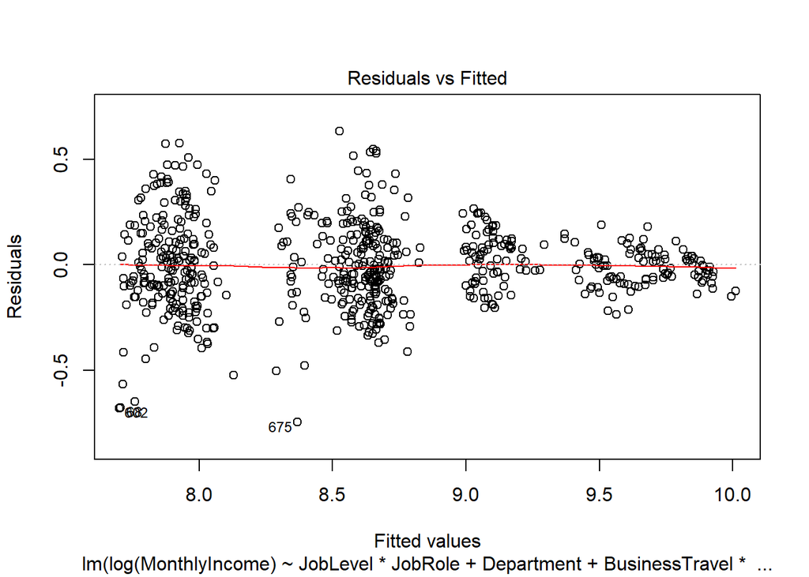

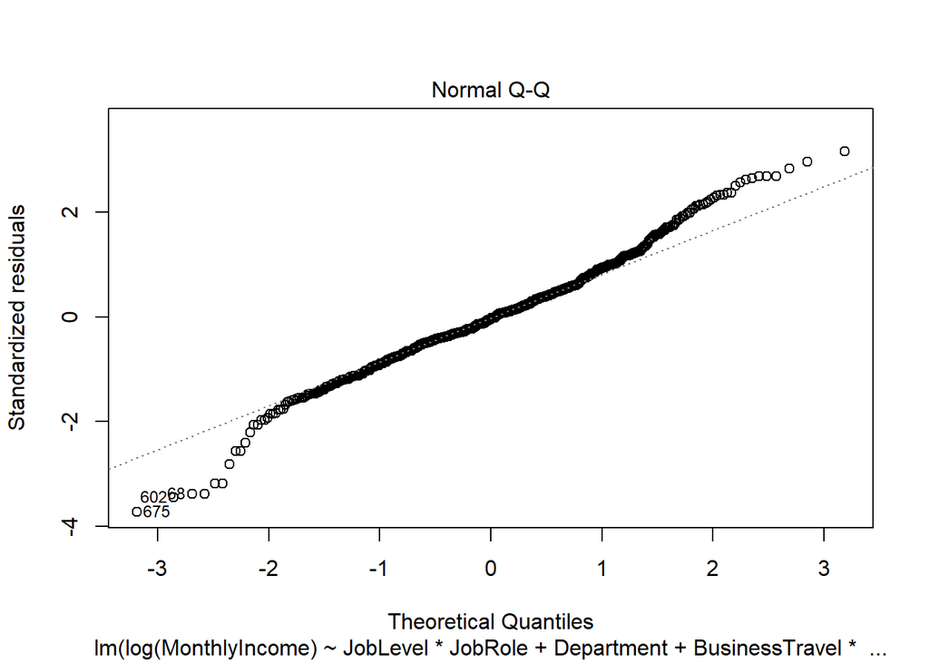

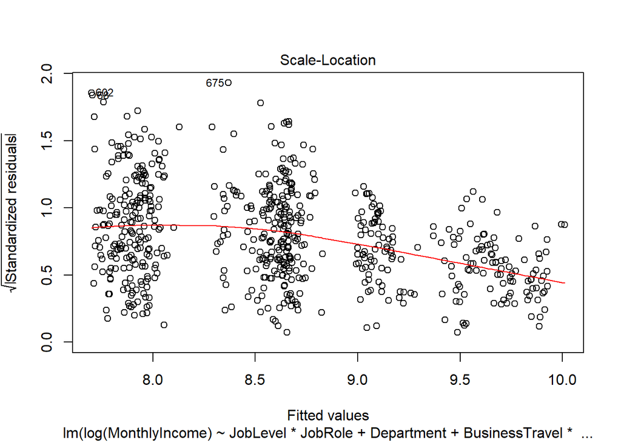

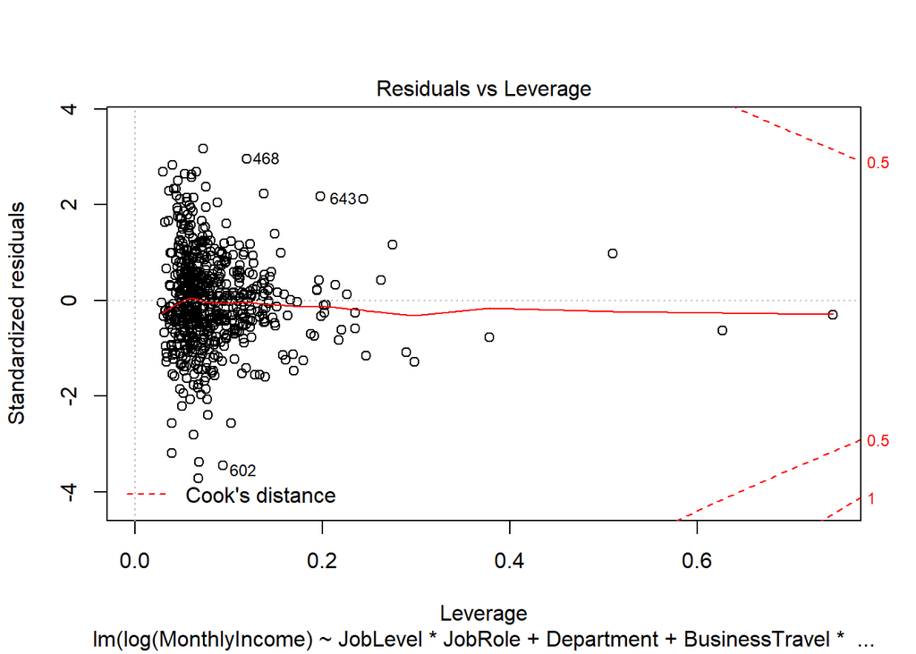

```r
plot(lr.employee.inc)
```

Show detailed plots of Interactions

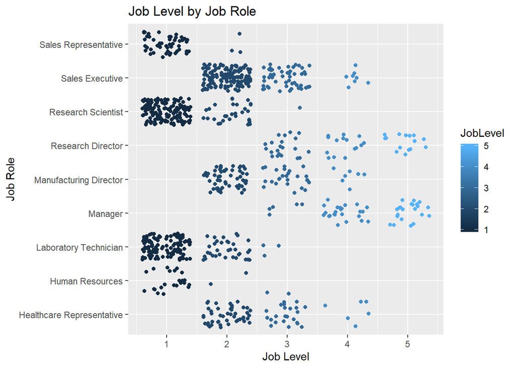

```r
#####  Plot the Interactions #####



employee %>% ggplot(aes(x = JobLevel,y=JobRole,col=JobLevel)) + geom_point(pos='Jitter') + ggtitle("Job Level by Job Role ") +
    xlab ("Job Level") +
    ylab ("Job Role")
```

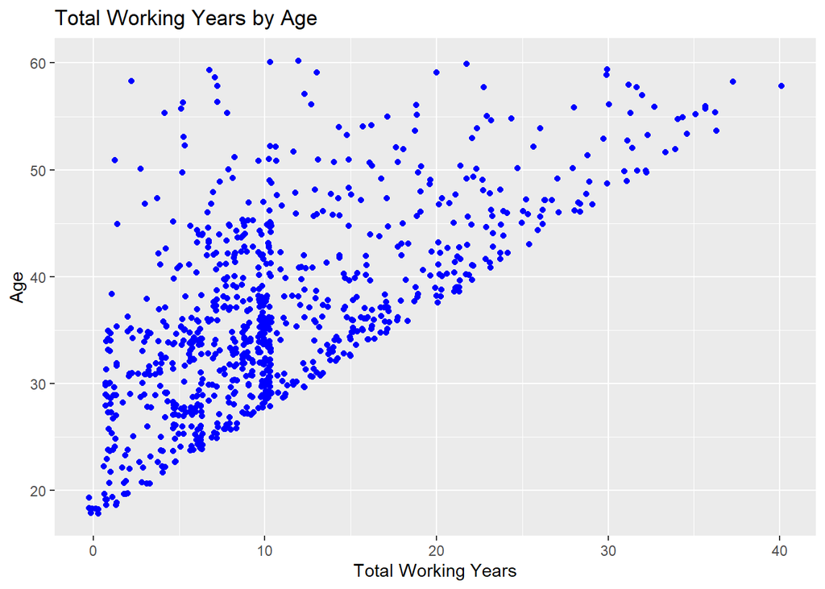

```r
employee %>% ggplot(aes(x = TotalWorkingYears,y=Age)) + geom_point(col='Blue',pos='Jitter') + ggtitle("Total Working Years by Age ") +
    xlab ("Total Working Years") +
    ylab ("Age")
```

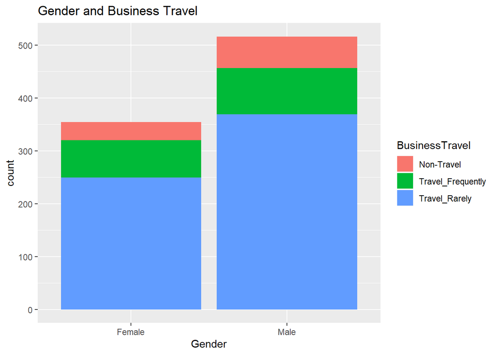

```r
employee %>% ggplot(aes(x = Gender, fill=BusinessTravel)) + geom_bar(stat='count') +
    xlab ("Gender") + ggtitle ("Gender and Business Travel")
```

[figure not shown]

```r
employee %>% ggplot(aes(x = Education, fill=EducationField)) + geom_bar(stat='count') +
    xlab ("Gender") + ggtitle ("Gender and Business Travel")
```

Run the Linear Regression Employee Salary Predictions

```r
######  Linear Model Predictions
lr.employee.predI <- data.frame(predict(lr.employee.inc, newdata  = test, type = "response"))
newdf = NewIncome=data.frame(exp(lr.employee.predI))


####  Run on competition dataset

lr.employee.predI <- data.frame(predict(lr.employee.inc, newdata  = employeenoinc, type = "response"))
preddf = NewIncome=data.frame(exp(lr.employee.predI))
names(preddf) <- c("PredictIncome")
IncomePred <- cbind(employeenoinc[1],preddf)

write.csv(IncomePred,'c:/School Stuff/DS/Doing DS/Project2/Case2PredictionsLull Salary.csv')
```

Managers and Directors Rarely Leave but Job Satisfaction Rating is not Significant

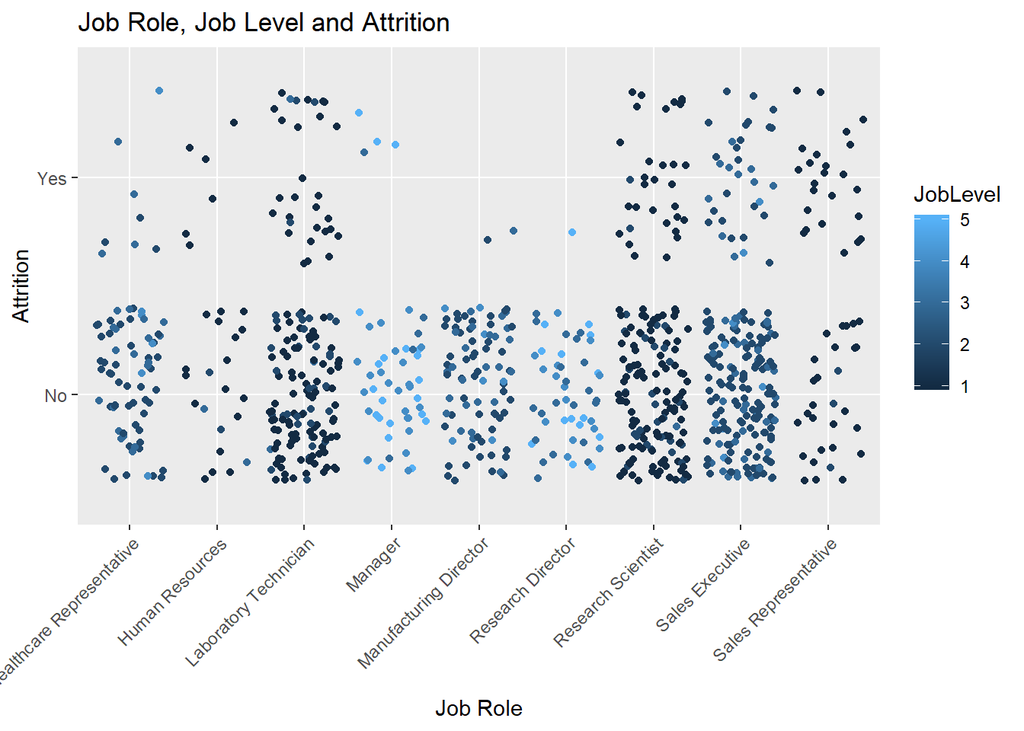

```r
employee %>% ggplot(aes(x = JobRole,y=Attrition,col=JobLevel)) + geom_point(pos='Jitter') + ggtitle("Job Role, Job Level and Attrition") +
    xlab ("Job Role") +
    ylab ("Attrition") + theme(axis.text.x=element_text(angle=45, hjust=1))
```

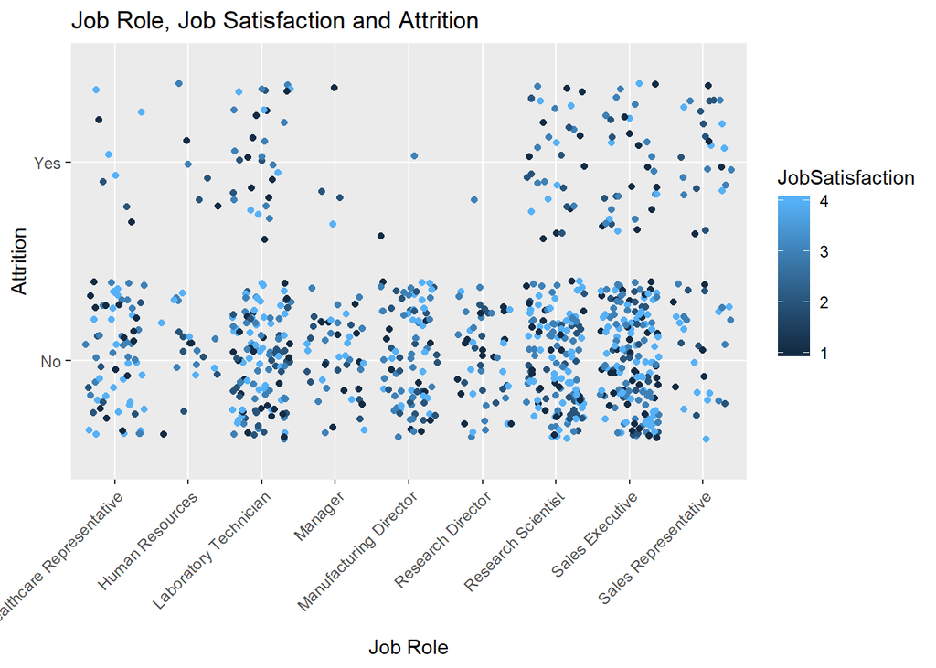

```r
employee %>% ggplot(aes(x = JobRole,y=Attrition,col=JobSatisfaction)) + geom_point(pos='Jitter') + ggtitle("Job Role, Job Satisfaction and Attrition") +
    xlab ("Job Role") +
    ylab ("Attrition") + theme(axis.text.x=element_text(angle=45, hjust=1))
```

```r
 newemp <- employee %>% filter(JobLevel>3 & JobRole %in% c("Manager", "Manufacturing Director","Research Director"))

t.test(newemp$JobSatisfaction, var.equal=F, mu=2,alternative='less')
```

```
##
##  One Sample t-test
##
## data:  newemp$JobSatisfaction
## t = 4.918, df = 82, p-value = 1
## alternative hypothesis: true mean is less than 2
## 95 percent confidence interval:
##      -Inf 2.790066
## sample estimates:
## mean of x
##  2.590361
```

### Top 3 Categories Of the varaibles picked in the best model, these changed the sensitivity and specificity the least

```r
AttritionYes = employee %>%  filter(Attrition == "Yes")
AttritionNo = employee %>%  filter(Attrition == "No")

###  Same test train split as before.  Picked top most influential Variables
set.seed(9)
trainInd = sample(seq(1,dim(AttritionYes)[1],1),round(.7*dim(AttritionYes)[1]))
trainYES = AttritionYes[trainInd,]
testYES = AttritionYes[-trainInd,]

trainInd = sample(seq(1,dim(AttritionNo)[1],1),round(.7*dim(AttritionNo)[1]))
train = AttritionNo[trainInd,]
test = AttritionNo[-trainInd,]

train = rbind(train,trainYES)
test = rbind(test,testYES)



lr.employee <-glm(Attrition~TotalWorkingYears + JobRole + WorkLifeBalance,data=train,family=binomial(link="logit"))

lr.employee.pred2 <- data.frame(predict(lr.employee, newdata  = test, type = "response"))
lr.employee.pred2 = lr.employee.pred2 %>% mutate(pred = ifelse(lr.employee.pred2 <0.25, "No", "Yes"))

table(lr.employee.pred2$pred)
```

```
##
##  No Yes
## 220  41
```

```r
predtble = as.factor(lr.employee.pred2$pred)
predtble  <-relevel(predtble, ref = "No")
Truth<-test$Attrition
confmtx = as.matrix(table(predtble,Truth))
CM = confusionMatrix(confmtx)
CM
```

```
## Confusion Matrix and Statistics
##
##         Truth
## predtble  No Yes
##      No  196  24
##      Yes  23  18
##
##                Accuracy : 0.8199
##                  95% CI : (0.7678, 0.8646)
##     No Information Rate : 0.8391
##     P-Value [Acc > NIR] : 0.8237
##
##                   Kappa : 0.3267
##
##  Mcnemar's Test P-Value : 1.0000
##
##             Sensitivity : 0.8950
##             Specificity : 0.4286
##          Pos Pred Value : 0.8909
##          Neg Pred Value : 0.4390
##              Prevalence : 0.8391
##          Detection Rate : 0.7510
##    Detection Prevalence : 0.8429
##       Balanced Accuracy : 0.6618
##
##        'Positive' Class : No
##
```

```r
employee$WorkYrFactor = cut(employee$TotalWorkingYears, breaks = c(0,10,20,30,50), labels = c("< 10","10-20", "20-30","Above 30"))

nbemploy <- data.frame(WorkLifeBalance = factor(employee$WorkLifeBalance),JobLevel = factor(employee$JobLevel),employee$WorkYrFactor,Attrition=employee$Attrition)

model = naiveBayes(Attrition~.,data = nbemploy)
tp=predict(model,nbemploy[,c('Attrition')])
Truth=employee$Attrition
confmtx = as.matrix(table(tp,Truth))
CM = confusionMatrix(confmtx)
CM
```

```
## Confusion Matrix and Statistics
##
##      Truth
## tp     No Yes
##   No  730 140
##   Yes   0   0
##
##                Accuracy : 0.8391
##                  95% CI : (0.8129, 0.8629)
##     No Information Rate : 0.8391
##     P-Value [Acc > NIR] : 0.5225
##
##                   Kappa : 0
##
##  Mcnemar's Test P-Value : <2e-16
##
##             Sensitivity : 1.0000
##             Specificity : 0.0000
##          Pos Pred Value : 0.8391
##          Neg Pred Value :    NaN
##              Prevalence : 0.8391
##          Detection Rate : 0.8391
##    Detection Prevalence : 1.0000
##       Balanced Accuracy : 0.5000
##
##        'Positive' Class : No
##
```